# Correlation and Regression

[Sushank Pokhrel (Homepage)](https://sushank.com.np)

We are working with the trees dataset from the base R datasets package. This dataset contains measurements of the girth (in inches), height (in feet), and volume (in cubic feet) of black cherry trees.

Loading Required Libraries

```r
library(datasets)  # Loads the built-in datasets in R
library(help = "datasets")  # Lists all datasets available in the package
```

`datasets` contains multiple datasets for practicing data analysis in R. Let’s load trees datasets.

```r
head(trees)
```

```
##   Girth Height Volume
## 1   8.3     70   10.3
## 2   8.6     65   10.3
## 3   8.8     63   10.2
## 4  10.5     72   16.4
## 5  10.7     81   18.8
## 6  10.8     83   19.7
```

### 1. Correlation Analysis

Correlation measures the strength and direction of the linear relationship between two continuous variables.

```r
cor.test(trees$Girth, trees$Height)
```

```
##
##  Pearson's product-moment correlation
##
## data:  trees$Girth and trees$Height
## t = 3.2722, df = 29, p-value = 0.002758
## alternative hypothesis: true correlation is not equal to 0
## 95 percent confidence interval:
##  0.2021327 0.7378538
## sample estimates:
##       cor
## 0.5192801
```

```r
cor.test(trees$Volume, trees$Girth)
```

```
##
##  Pearson's product-moment correlation
##
## data:  trees$Volume and trees$Girth
## t = 20.478, df = 29, p-value < 2.2e-16
## alternative hypothesis: true correlation is not equal to 0
## 95 percent confidence interval:
##  0.9322519 0.9841887
## sample estimates:
##       cor
## 0.9671194
```

```r
cor.test(trees$Volume, trees$Height)
```

```
##
##  Pearson's product-moment correlation
##
## data:  trees$Volume and trees$Height
## t = 4.0205, df = 29, p-value = 0.0003784
## alternative hypothesis: true correlation is not equal to 0
## 95 percent confidence interval:
##  0.3095235 0.7859756
## sample estimates:
##       cor
## 0.5982497
```

- `cor.test()`: This function tests the null hypothesis that the correlation between two variables is zero.
- `trees$Girth`: Fetches Girth column of trees dataset.
- `trees$Height`: Fetches Height column of trees dataset.
- `trees$Volume`: Fetches Volume column of trees dataset.

The test provides the correlation coefficient (𝑟) and a p-value. A significant 𝑝< 0.05 indicates a strong relationship.

Alternatively,

```r
cor(trees$Girth, trees$Height)
```

```
## [1] 0.5192801
```

```r
cor(trees$Volume, trees$Girth)
```

```
## [1] 0.9671194
```

```r
cor(trees$Volume, trees$Height)
```

```
## [1] 0.5982497
```

### 2. Linear Regression

Regression is used to model the relationship between a dependent variable (Volume) and one or more independent variables (Girth).

```r
volume_line <- lm(data = trees, formula = Volume ~ Girth)
summary(volume_line)
```

```
##
## Call:
## lm(formula = Volume ~ Girth, data = trees)
##
## Residuals:
##    Min     1Q Median     3Q    Max
## -8.065 -3.107  0.152  3.495  9.587
##
## Coefficients:
##             Estimate Std. Error t value Pr(>|t|)
## (Intercept) -36.9435     3.3651  -10.98 7.62e-12 ***
## Girth         5.0659     0.2474   20.48  < 2e-16 ***
## ---
## Signif. codes:  0 '***' 0.001 '**' 0.01 '*' 0.05 '.' 0.1 ' ' 1
##
## Residual standard error: 4.252 on 29 degrees of freedom
## Multiple R-squared:  0.9353, Adjusted R-squared:  0.9331
## F-statistic: 419.4 on 1 and 29 DF,  p-value: < 2.2e-16
```

- `lm()`: Fits a linear regression model.
- `data = trees`: Specifies the dataset.
- `Volume ~ Girth`: Formula defining Volume as the dependent variable and Girth as the independent variable.

`summary()`: Summarizes the regression model, providing:

- Coefficients: Intercept (𝑐) and slope (𝑚).
- R-squared (𝑅^2): Indicates the proportion of variance explained by the model.
- P-value: Tests the significance of the predictor.
- Example Equation:Volume = 5.0659 × Girth − 36.9435
- 𝑅^2 = 0.93 : Indicates that 93% of the variation in volume is explained by girth.

Visualizing the Basic Linear Regression Plot

```r
library(tidyverse)
```

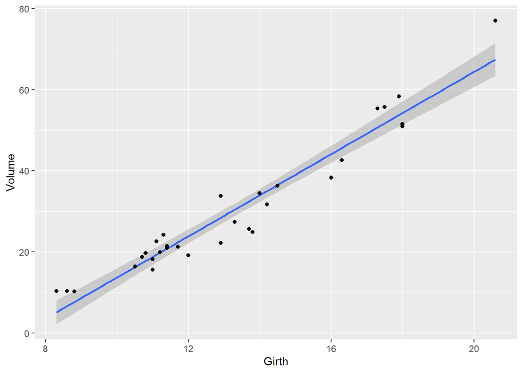

```r
ggplot() +
  geom_smooth(data = trees, aes(x = Girth, y = Volume), method = "lm") +
  geom_point(data = trees, aes(x = Girth, y = Volume))
```

- `ggplot()`: Initiates a ggplot object for layered graphics.
- `geom_smooth()`: Adds a smoothed line for the regression model.
- `method = "lm"`: Specifies a linear model.
- `geom_point()`: Adds the scatter plot to show data points.

Adding the Regression Equation. We need the package `ggpmisc`

```r
library(ggpmisc) # install this package if not installed.
```

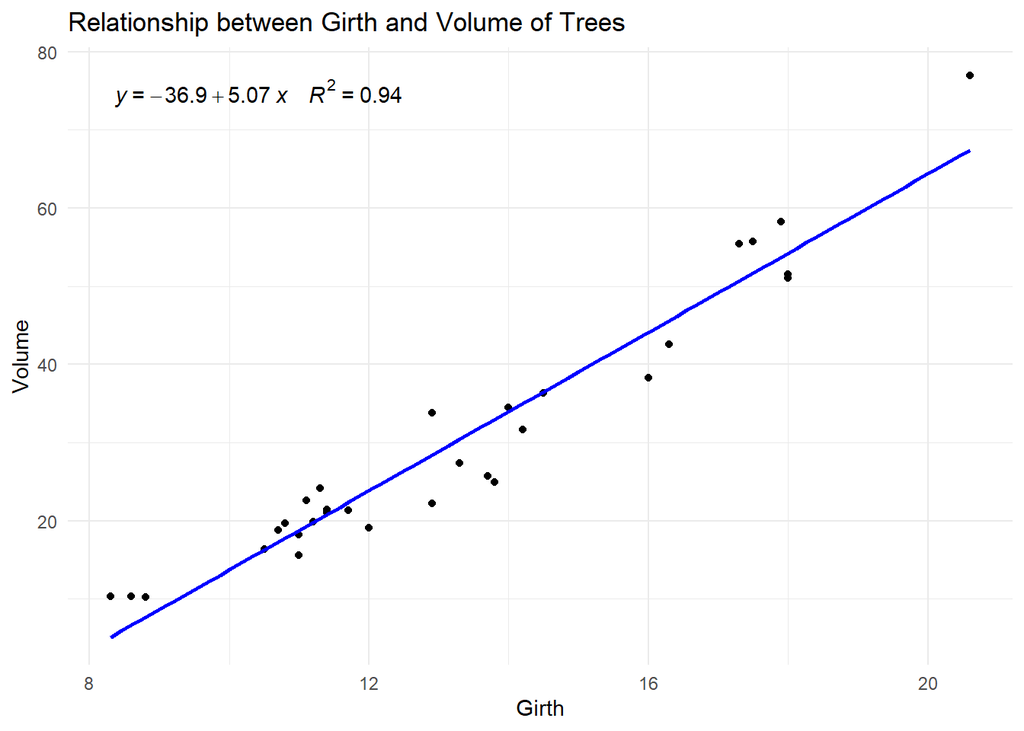

```r
ggplot(data = trees,
       aes(x = Girth,
           y = Volume)) +
  geom_point() +
  geom_smooth(method = "lm",
              se = FALSE,
              color = "blue") +
  stat_poly_eq(aes(label = paste(after_stat(eq.label),
                                 after_stat(rr.label),
                                 sep = "~~~~")),
               formula = y ~ x,
               parse = TRUE,
               color = "black") +
  labs(title = "Relationship between Girth and Volume of Trees") +
  theme_minimal()
```

- `stat_poly_eq()` (from ggpmisc): Displays the regression equation and 𝑅^2 value on the plot.
- `paste`: Displays the equation in the graph.
- `eq.label`: Specifically shows the equation in the plot.
- `rr.label`: Specifically shows the R-squared value.
- `sep`: Species the distance between equation and R-squared.
- `formula = y ~ x`: Specifies the formula for the linear model.

#### Predicting the Volume of tree using height.

```r
height_volume <- lm(data = trees, formula = Volume ~ Height)
summary(height_volume)
```

```
##
## Call:
## lm(formula = Volume ~ Height, data = trees)
##
## Residuals:
##     Min      1Q  Median      3Q     Max
## -21.274  -9.894  -2.894  12.068  29.852
##
## Coefficients:
##             Estimate Std. Error t value Pr(>|t|)
## (Intercept) -87.1236    29.2731  -2.976 0.005835 **
## Height        1.5433     0.3839   4.021 0.000378 ***
## ---
## Signif. codes:  0 '***' 0.001 '**' 0.01 '*' 0.05 '.' 0.1 ' ' 1
##
## Residual standard error: 13.4 on 29 degrees of freedom
## Multiple R-squared:  0.3579, Adjusted R-squared:  0.3358
## F-statistic: 16.16 on 1 and 29 DF,  p-value: 0.0003784
```

- The process is similar to the first regression, but the predictor is now Height. Overlaying Models in One Plot
- The model is not as strong as former one. It’s R-squared value is lesser.

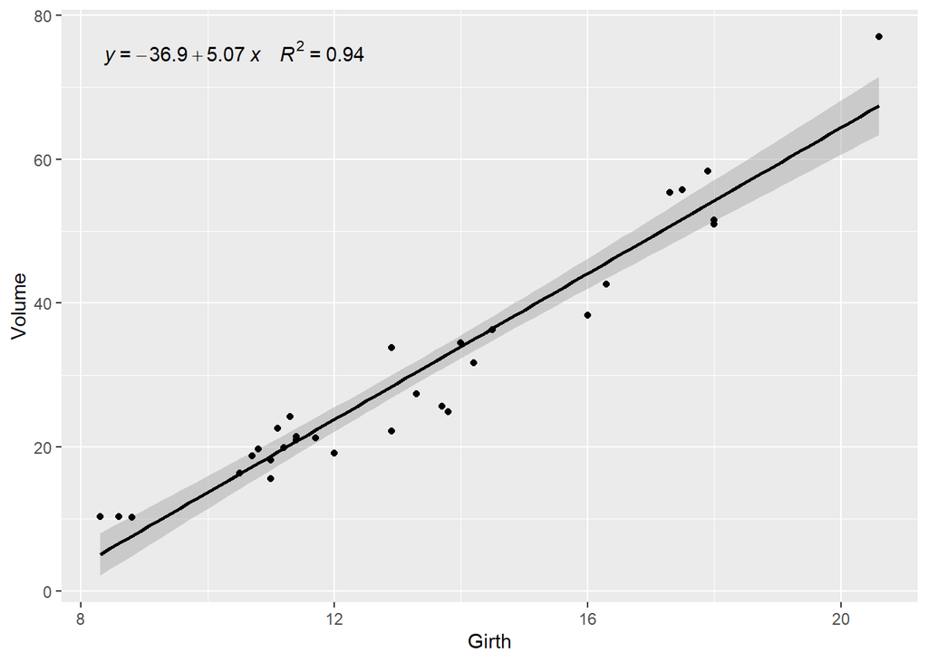

```r
ggplot() +
  geom_smooth(data = trees,
              aes(x = Girth,
                  y = Volume),
              method = "lm",
              color = "black") +
  geom_point(data = trees,
             aes(x = Girth,
                 y = Volume),
             color = "black") +
  stat_poly_eq(data = trees,
               aes(x = Girth,
                   y = Volume,
                   label = paste(after_stat(eq.label),
                                 after_stat(rr.label),
                                 sep = "~~~~")),
               formula = y ~ x,
               parse = TRUE,
               color = "black")
```

### 3. Multiple Linear Regression

In a multiple linear regression, we assess the combined effect of two or more independent variables (predictors) on a dependent variable. Here, we use both Girth and Height to predict Volume.

Fitting the Model

```r
girth_height_lm <- lm(
  data = trees,
  formula = Volume ~ Girth + Height
)

girth_height_lm
```

```
##
## Call:
## lm(formula = Volume ~ Girth + Height, data = trees)
##
## Coefficients:
## (Intercept)        Girth       Height
##    -57.9877       4.7082       0.3393
```

```r
girth_height_lm |> summary()
```

```
##
## Call:
## lm(formula = Volume ~ Girth + Height, data = trees)
##
## Residuals:
##     Min      1Q  Median      3Q     Max
## -6.4065 -2.6493 -0.2876  2.2003  8.4847
##
## Coefficients:
##             Estimate Std. Error t value Pr(>|t|)
## (Intercept) -57.9877     8.6382  -6.713 2.75e-07 ***
## Girth         4.7082     0.2643  17.816  < 2e-16 ***
## Height        0.3393     0.1302   2.607   0.0145 *
## ---
## Signif. codes:  0 '***' 0.001 '**' 0.01 '*' 0.05 '.' 0.1 ' ' 1
##
## Residual standard error: 3.882 on 28 degrees of freedom
## Multiple R-squared:  0.948,  Adjusted R-squared:  0.9442
## F-statistic:   255 on 2 and 28 DF,  p-value: < 2.2e-16
```

- `Volume ~ Girth + Height`: Specifies the formula with two predictors, Girth and Height.

From the output: `Volume = -57.9877 + 4.7082 * Girth + 0.3393 * Height`

Checking Multicollinearity Multicollinearity occurs when predictors are highly correlated, which can destabilize regression coefficients. Pearson correlation coefficient and Variance Inflation Factor (VIF) is used to detect this.

```r
cor(trees[ , -3])
```

```
##            Girth    Height
## Girth  1.0000000 0.5192801
## Height 0.5192801 1.0000000
```

We calculated the person correlation coefficient between Girth and Height of the trees. Generally, the parameters with correlation > |0.7| are removed from the final model, due to their greater collinearity. The correlation matrix is provided in order to study the correlation.

Furtherore, We calculate VIF of the model, for which the package `car` is required. Install the package if not already installed.

```r
car::vif(girth_height_lm) # diectly fetching the function of the package without loading library.
```

```
##   Girth  Height
## 1.36921 1.36921
```

- VIF>10: High multicollinearity (problematic). However, in some studies, VIF>5 is considered problematic and is rejected. VIF ≤2 is considered the best.
- Low VIF values indicated minimal multicollinearity between Girth and Height, ensuring the model is stable and reliable. Visualizing Relationships

Plotting All Combinations in a Single Plot

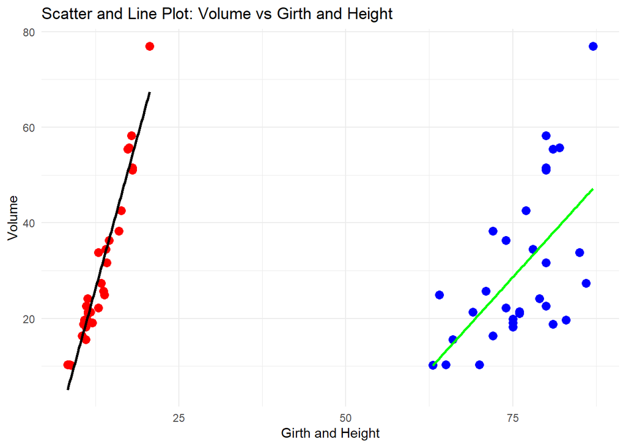

```r
ggplot(trees) +
  geom_point(aes(x = Girth, y = Volume), color = "red", size = 3) +
  geom_point(aes(x = Height, y = Volume), color = "blue", size = 3) +
  geom_smooth(aes(x = Girth, y = Volume), method = "lm", color = "black", se = FALSE) +
  geom_smooth(aes(x = Height, y = Volume), method = "lm", color = "green", se = FALSE) +
  labs(
    title = "Scatter and Line Plot: Volume vs Girth and Height",
    x = "Girth and Height",
    y = "Volume"
  ) +
  theme_minimal()
```

Not always recommended to develop this plot.